# DataHack- Upworthy

## Research Question

1. Did Upworthy really change their clickbait publishing practices?
2. What was the impact of that change?
3. Do you recommend an investment in Upworthy?

Read CSV files

```r
country_df = read.csv("country-data.csv") # aggregates user analytics by country
daily_user_df = read.csv("daily-user-info.csv") # user analytics from 2013 to 2015
archive_df = read.csv("upworthy-archive.csv") # A/B testing results
```

Import packages

```r
library(dplyr)
```

```r
library(ggplot2)
library(stringr)
```

## Initial Analysis with Generalized Linear Models

We first defined clickbait as something that is *attention-grabbing*, *emotionally arousing*, and *misleading*. Since, there are three different datasets with a total of 31 variables, we were able to consider different metrics for clickbait such as the clicks per impressions, the language of the headline, and the bounce rate of the article.

```r
# Data Wrangling

# create numeric variable of winner for logistic regression
archive_df$bWinner <- as.numeric(as.logical(archive_df$winner))
# create clicks per impression variable
archive_df$click_imp <- archive_df$clicks / archive_df$impressions
```

### Data Analysis on Clicks per Impression

```r
click_glm = glm(bWinner ~ click_imp, data = archive_df)
summary(click_glm)
```

```
##
## Call:
## glm(formula = bWinner ~ click_imp, data = archive_df)
##
## Deviance Residuals:
##      Min        1Q    Median        3Q       Max
## -0.45666  -0.05921  -0.04063  -0.02840   0.98741
##
## Coefficients:
##              Estimate Std. Error t value Pr(>|t|)
## (Intercept) 0.0125876  0.0009084   13.86   <2e-16 ***
## click_imp   2.4213110  0.0452874   53.47   <2e-16 ***
## ---
## Signif. codes:  0 '***' 0.001 '**' 0.01 '*' 0.05 '.' 0.1 ' ' 1
##
## (Dispersion parameter for gaussian family taken to be 0.04733763)
##
##     Null deviance: 7274.5  on 150816  degrees of freedom
## Residual deviance: 7139.2  on 150815  degrees of freedom
## AIC: -32056
##
## Number of Fisher Scoring iterations: 2
```

```r
score_glm = glm(bWinner ~ score, data = archive_df)
summary(score_glm)
```

```
##
## Call:
## glm(formula = bWinner ~ score, data = archive_df)
##
## Deviance Residuals:
##      Min        1Q    Median        3Q       Max
## -0.14370  -0.09941  -0.01599   0.01108   1.01280
##
## Coefficients:
##               Estimate Std. Error t value Pr(>|t|)
## (Intercept) -1.280e-02  7.752e-04  -16.52   <2e-16 ***
## score        1.565e-03  1.363e-05  114.84   <2e-16 ***
## ---
## Signif. codes:  0 '***' 0.001 '**' 0.01 '*' 0.05 '.' 0.1 ' ' 1
##
## (Dispersion parameter for gaussian family taken to be 0.04435583)
##
##     Null deviance: 7274.5  on 150816  degrees of freedom
## Residual deviance: 6689.5  on 150815  degrees of freedom
## AIC: -41868
##
## Number of Fisher Scoring iterations: 2
```

```r
cor.test(archive_df$bWinner, archive_df$click_imp)
```

```
##
##  Pearson's product-moment correlation
##
## data:  archive_df$bWinner and archive_df$click_imp
## t = 53.465, df = 150815, p-value < 2.2e-16
## alternative hypothesis: true correlation is not equal to 0
## 95 percent confidence interval:
##  0.1314308 0.1413368
## sample estimates:
##       cor
## 0.1363872
```

```r
cor.test(archive_df$bWinner, archive_df$score)
```

```
##
##  Pearson's product-moment correlation
##
## data:  archive_df$bWinner and archive_df$score
## t = 114.84, df = 150815, p-value < 2.2e-16
## alternative hypothesis: true correlation is not equal to 0
## 95 percent confidence interval:
##  0.2789364 0.2882184
## sample estimates:
##       cor
## 0.2835841
```

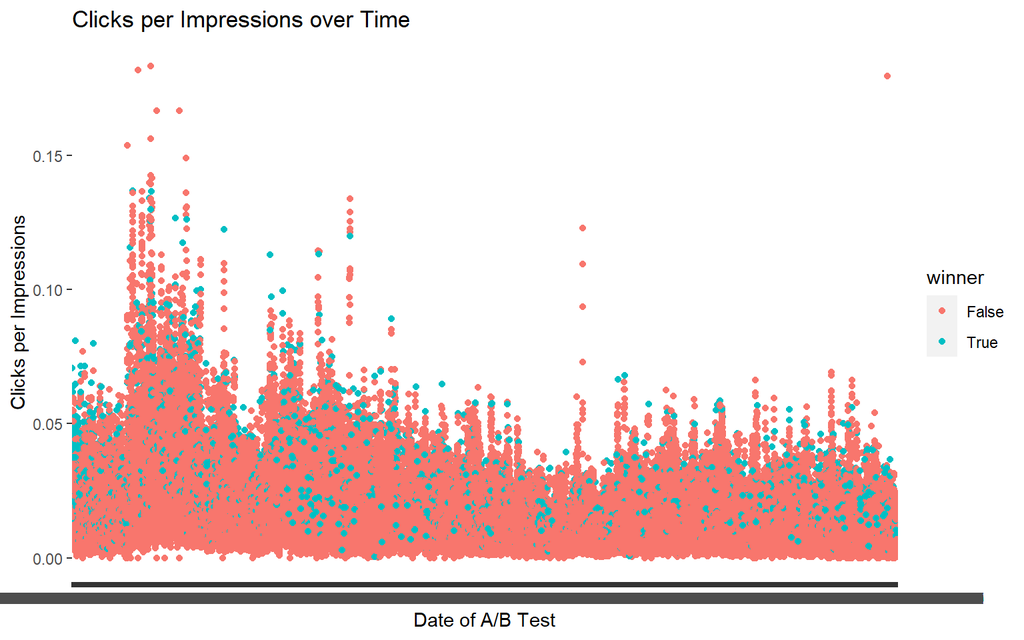

```r
ggplot(archive_df, aes(x = created_at, y = click_imp)) + geom_point(aes(color = winner)) + geom_smooth() + labs(title = "Clicks per Impressions over Time", x= "Date of A/B Test", y = "Clicks per Impressions")
```

## Text Mining Headlines

```r
# using punctuation to evaluate clickbait
punctuations.dict <- c(question = "?",
                       quote = "'",
                       dollar = "$",
                       exclaim = "!")
archive_df$created_at <- as.Date(archive_df$created_at)
archive_df$headline_nchar <- archive_df$package_headline %>% nchar()
archive_df$headline_nwords <- archive_df$package_headline %>% str_count(" ") + 1

for(i in punctuations.dict %>% names()){archive_df[[i]] <- ifelse(grepl(paste0("[",punctuations.dict[i],"]"), archive_df$package_headline), T, F) }
```

### Data Visualization on Punctuation

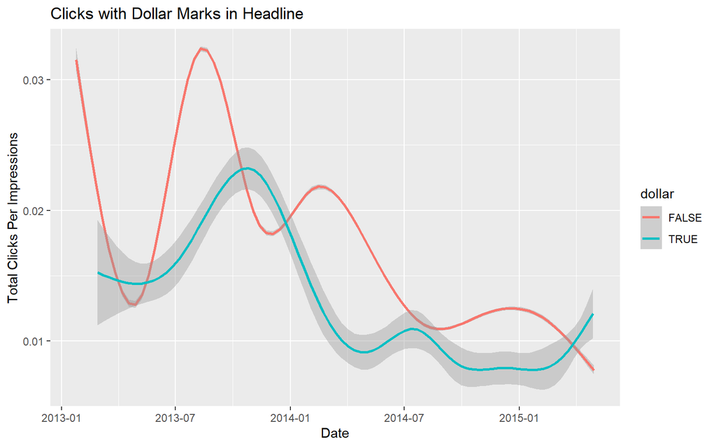

```r
archive_df %>% ggplot(aes(created_at, clicks/impressions, color = dollar)) + geom_smooth() + labs(title = "Clicks with Dollar Marks in Headline", x= "Date", y= "Total Clicks Per Impressions")
```

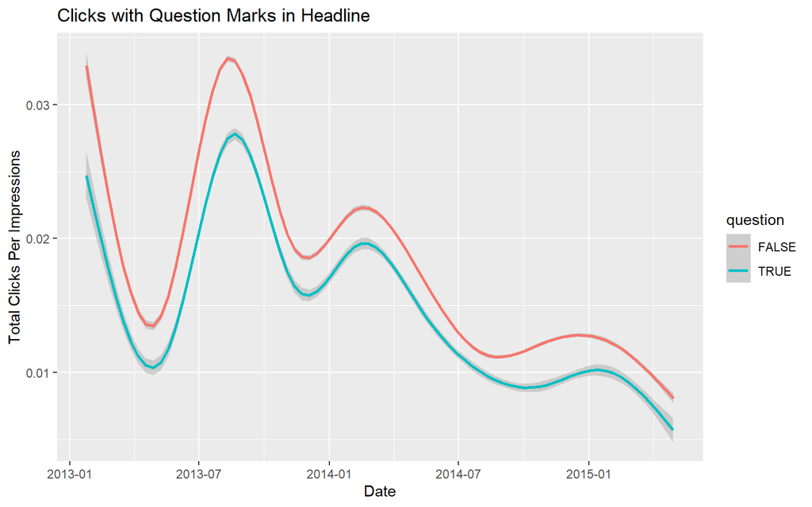

```r
archive_df %>% ggplot(aes(created_at, clicks/impressions, color = question)) + geom_smooth()+ labs(title = "Clicks with Question Marks in Headline", x= "Date", y= "Total Clicks Per Impressions")
```

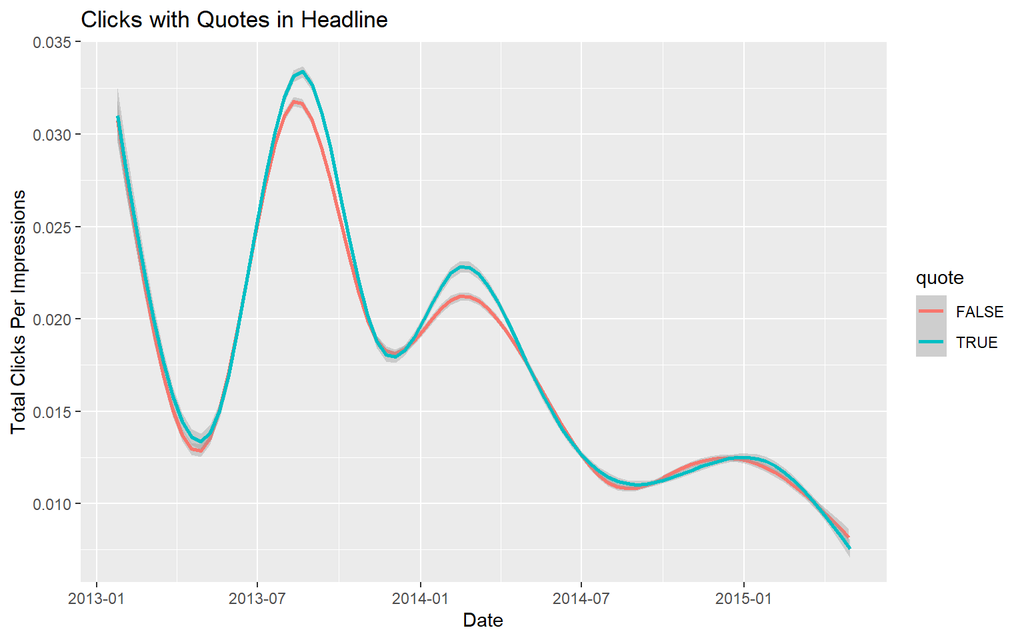

```r
archive_df %>% ggplot(aes(created_at, clicks/impressions, color = quote)) + geom_smooth() + labs(title = "Clicks with Quotes in Headline", x= "Date", y= "Total Clicks Per Impressions")
```

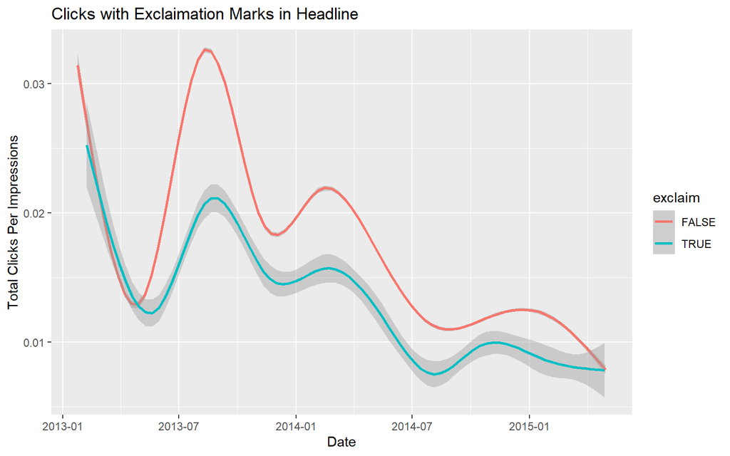

```r
archive_df %>% ggplot(aes(created_at, clicks/impressions, color = exclaim)) + geom_smooth() + labs(title = "Clicks with Exclaimation Marks in Headline", x= "Date", y= "Total Clicks Per Impressions")
```

```r
model.1 <- lm(click_imp ~ question+exclaim+dollar+quote+headline_nchar+headline_nwords, data = archive_df)
summary(model.1)
```

```
##
## Call:
## lm(formula = click_imp ~ question + exclaim + dollar + quote +
##     headline_nchar + headline_nwords, data = archive_df)
##
## Residuals:
##       Min        1Q    Median        3Q       Max
## -0.017568 -0.008247 -0.003231  0.004563  0.168565
##
## Coefficients:
##                   Estimate Std. Error t value Pr(>|t|)
## (Intercept)      1.236e-02  1.827e-04  67.614  < 2e-16 ***
## questionTRUE    -1.842e-03  8.843e-05 -20.827  < 2e-16 ***
## exclaimTRUE     -3.056e-03  2.342e-04 -13.047  < 2e-16 ***
## dollarTRUE      -3.694e-03  3.939e-04  -9.380  < 2e-16 ***
## quoteTRUE       -5.645e-04  6.508e-05  -8.674  < 2e-16 ***
## headline_nchar   7.186e-05  4.141e-06  17.353  < 2e-16 ***
## headline_nwords -1.237e-04  1.980e-05  -6.250 4.12e-10 ***
## ---
## Signif. codes:  0 '***' 0.001 '**' 0.01 '*' 0.05 '.' 0.1 ' ' 1
##
## Residual standard error: 0.01232 on 150810 degrees of freedom
## Multiple R-squared:  0.008937,   Adjusted R-squared:  0.008897
## F-statistic: 226.7 on 6 and 150810 DF,  p-value: < 2.2e-16
```

After running a linear model, we confirmed that the punctuation marks led to significantly less clicks per impression with the exception of number of characters in the headline.

## Natural Language Processing Sentiment Analysis

To view the NLP sentiment analysis model, view the Colab Notebook here: https://colab.research.google.com/drive/11nhDAOWKevdZQ1J4-eo2g0YU_heuWFjF?usp=sharing

In summary, using pre-trained neural networks of HuggingFace, we identified clickbait using sentiment analysis models to see if a collection of text is positive or negative.

We evaluated that the overall strength of the sentiment does not decrease, but the headlines may be getting more positive near the date of the clickbait pledge.

In a breakdown of each emotion, we found that most articles either conveyed joy or anger. Additionally, there was an overall increase in sentiments for winner articles overtime.

## Time Series Analysis

### Loess Regression on Users

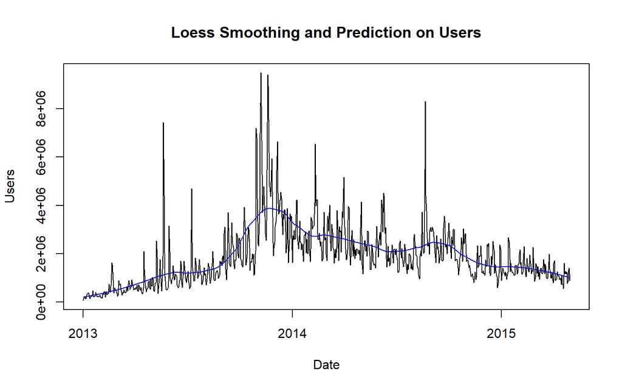

```r
# Wrangle date variable and prepare loess
daily_user_df$dayX <- as.Date(daily_user_df$day,format="%m/%d/%y")
daily_user_df$index <- 1:nrow(daily_user_df)

loess_users <- loess(users ~ index, data = daily_user_df, span=0.25)
smoothed_users <- predict(loess_users)

#create Loess regression
plot(y = daily_user_df$users, x = daily_user_df$dayX, type="l", main="Loess Smoothing and Prediction on Users", xlab="Date", ylab="Users")
lines(smoothed_users, x=daily_user_df$dayX, col="blue")
```

### Loess Regression on Bounce Rate

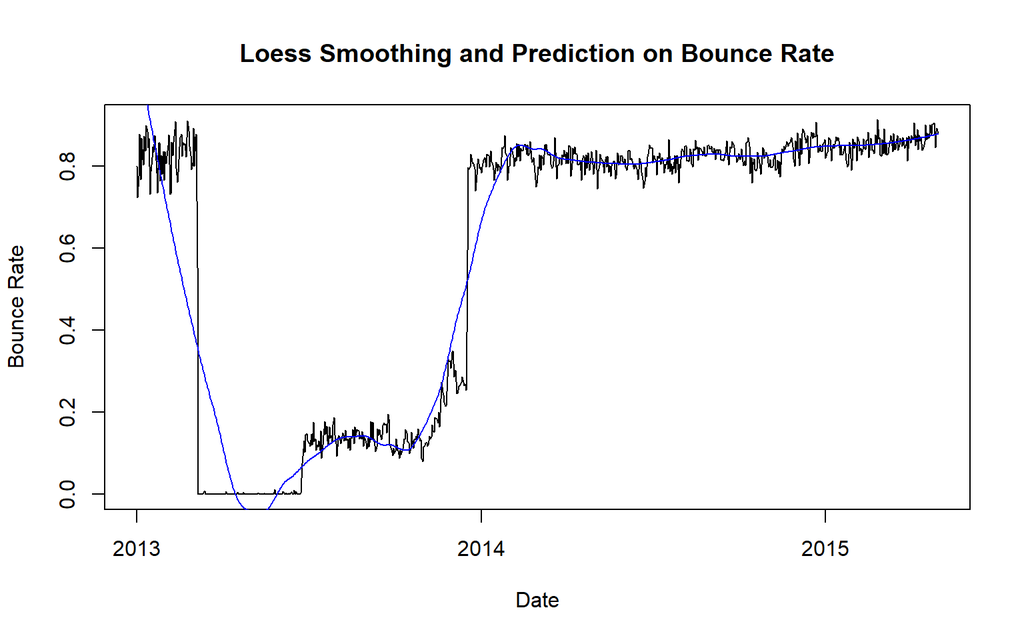

```r
loess_bounce <- loess(bounce_rate ~ index, data = daily_user_df, span=0.25)
smoothed_bounce <- predict(loess_bounce)

#create Loess regression
plot(y = daily_user_df$bounce_rate, x = daily_user_df$dayX, type="l", main="Loess Smoothing and Prediction on Bounce Rate", xlab="Date", ylab="Bounce Rate")
lines(smoothed_bounce, x=daily_user_df$dayX, col="blue")
```

After evaluating the clickbait in articles, we then investigated its impact on the company. Using a Loess Regression model, it is predicted that the bounce rate of the articles will stay consistent while the amount of users for the website will decrease.

## Conclusion

After analyzing different clickbait metrics such as clicks per impression, sentiment analysis, and bounce rate, we determined that Upworthy has not changed their clickbait publishing practices. However, the impact of the clickbait free pledge on the company has led to declining user engagement, retention, and new users. Due to the negative forecast on the website’s user analytics, we do not recomment an investment in Upworthy.